COC102 Advanced Artifical Intelligence Systems

# Training a Convolutional Neural Network at Multiclass Audio Classification

#### Elizabeth Sales (F124983)

## Introduction

A Convolutional Neural Network (CNN) is the standard architecture used for image recognition and classification. The structure does not require many parameters and can reuse its weights, making it ideal for comparing multiple samples against one another to discern any relevance. While on the surface it may seem like applying this neural network to audio classification problems would be an unusual choice, it is often quite common, and this tutorial will discuss a general method of training and testing a CNN on a set of audio files.

Learning Objectives:

- Converting audio (wave) files into spectrograms
- Creating a custom Dataset class
- Understanding data loaders at a basic level
- Creating CNNs within Pytorch
- Training and testing the CNNs for their accuracy and loss

Estimated Reading Time: 15 minutes

Required Libraries: Pytorch, Numpy, Matplotlib, Scipy, Pandas, Pillow

## Contents

1. Introduction
2. Contents
3. Preparing for the CNN Implementation
   - The Dataset
     - Converting from Audio to Spectrograms
   - Creating a Custom Dataset Class
   - Sorting the Dataset
4. Implementation
   - Starting "Simple"
     - Training
     - Predicting
   - Model Optimisation
   - Revisiting the "Simple" Model
5. Evaluation
   - The Dataset
   - Other Sources
6. Conclusion
7. References

## Preparing for the CNN Implementation

When preparing to tackle any kind of machine learning problem, one of the most important first steps is finding and organising the dataset. The set should be cleaned and normalised, converted into the correct format, and then split into subsets called training and testing sets. This section will cover the conversion and splitting of the GTZAN Dataset, which will be used throughout this tutorial.

### The Dataset

The [GTZAN Dataset](https://www.kaggle.com/datasets/andradaolteanu/gtzan-dataset-music-genre-classification) contains clipped music from 10 different genres and is frequently used for audio classification problems and music genre recognition (MGR). There are 1,000 files total, split equally across the genres, and the aim is to train the neural network to be able to classify audio files from each of them. The dataset comes with two additional .csv files which contain the features of the audio files at different lengths in seconds.

#### Converting from Audio to Spectrograms

For a CNN, the expected input is an image, so when working with audio (wave) files, they need to be converted into spectrograms. While the GTZAN Dataset comes with pre-made spectrogram images, this is uncommon, especially with more niche or custom made sets, so what follows is a demonstration of the process to obtaining custom spectrograms.

Note: As a small sample of the audio files will be used in this demonstration, altering the loops to iterate through all files must be done for other datasets.

Let's start by importing the audio files.

```python
#Import the necessary libraries
import os
import random

#Path to the folder of wave files
audio_direc = 'D:\\Advanced AI Systems\\Data\\genres_original'
#Subfolders within audio directory
labels = ["blues", "classical", "country", "disco", "hiphop", "jazz", "metal", "pop", "reggae", "rock"]

#Converting a sample for demonstration
spectrogram_samples = [0] * 10
for l in labels:
    audio_files = os.listdir(audio_direc + "\\" + l)

    n = random.randrange(100)
    print(audio_files[n]) #Display one sample from each category

    spectrogram_samples[labels.index(l)] = audio_files[n] #Save those for spectrogram conversion
```

```
blues.00058.wav
classical.00045.wav
country.00060.wav
disco.00058.wav
hiphop.00078.wav
jazz.00073.wav
metal.00054.wav
pop.00023.wav
reggae.00059.wav
rock.00089.wav
```

Here we have a sample containing one file from each folder. Now let's convert these into spectrogram images.

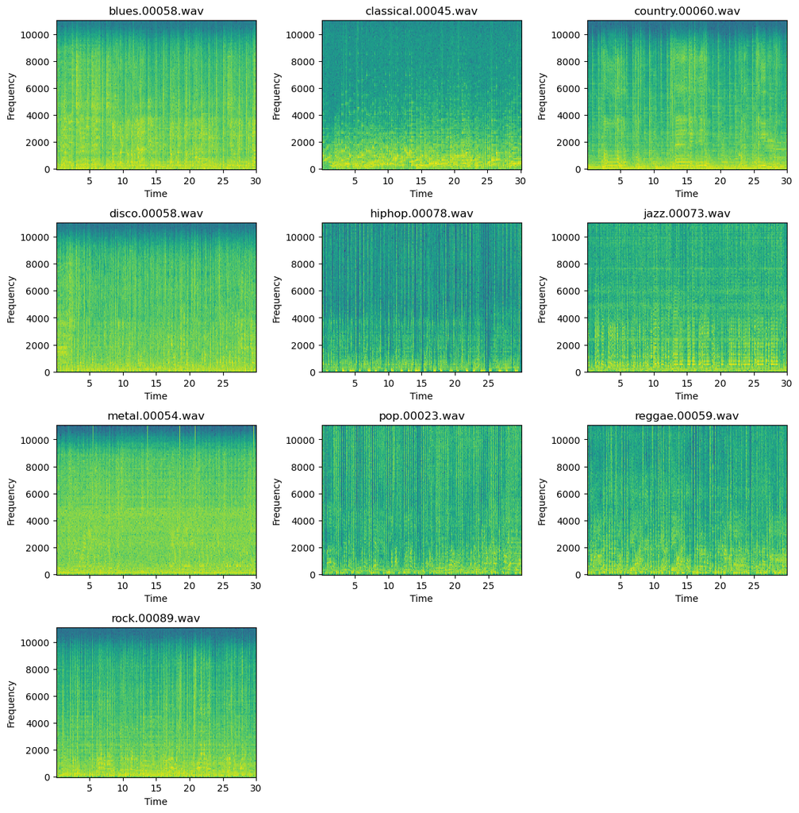

```python
#More libraries to import...
import numpy as np
import matplotlib.pyplot as plt
from scipy import signal
from scipy.io import wavfile

plt.figure(figsize=(12,12))

for i in range(10):
    #Locate the specific audio file
    sample_direc = audio_direc + "\\" + labels[i] + "\\" + spectrogram_samples[i]

    #Convert to a spectrogram format
    #From source [4]
    sample_rate, samples = wavfile.read(sample_direc)
    frequencies, times, spectrogram = signal.spectrogram(samples, sample_rate)

    #End of source [4]

    ax = plt.subplot(4, 3, i+1)
    plt.tight_layout()

    #Plot the spectrogram
    plt.pcolormesh(times, frequencies, np.log(spectrogram))

    #Title of the graph
    plt.title(spectrogram_samples[i])

    #Labels for x and y axes
    plt.xlabel("Time")
    plt.ylabel("Frequency")

plt.show()
```

Now we have a unique spectrogram for each file we imported. In order to save these spectrograms, we can use [matplotlib.pyplot.subplot](https://matplotlib.org/stable/api/_as_gen/matplotlib.pyplot.subplot.html) and iterate through all of the audio files in batches. For large datasets, do not display all of the spectrograms; save them directly to a folder within the dataset directory.

Changing the colour mesh can allow for different results when training and testing, for example a CNN will only require 1 channel when passing a gray-scale image through and will return worse results. Experimenting with these options could improve the accuracy of the model and is recommended.

### Creating a Custom Dataset Class

Pytorch has a range of inbuilt datasets that are pre-prepared for neural network training, with presplit arrays and compatibility with Pytorch functions. However, when using a custom dataset, we're required to build our own class to achieve the same functionality. This class will take in all of the image files, crop and convert them into tensors, before pairing them up with their respective label.

Note: For the GTZAN Dataset specifically, the pre-made spectrogram images contained a white border. This is removed using the crop_image method, and is not required for every custom dataset.

```python
#Even more libraries
import pandas as pd
import os
from PIL import Image
from torchvision import transforms
from torch.utils.data import Dataset
from torchvision.transforms.functional import crop

#Import .csv file containing the features
features_file = "D:\\Advanced AI Systems\\Data\\features_30_sec.csv"
#Import directory to all image files
image_dir = "D:\\Advanced AI Systems\\Data\\images_original"

#Custom Dataset Class
#Dataset Class from source [1]
class GTZANDataset(Dataset):
    #Class constructor
    def __init__(self, annotations_file, image_dir):
        self.image_labels = pd.read_csv(annotations_file)
        self.image_dir = image_dir

    def __len__(self):
        return len(self.image_labels)

    def __getitem__(self, index):
        image_path = os.path.join(self.image_dir, self.image_labels.iloc[index, 59], self.image_labels.iloc[index, 0])

        image = Image.open(image_path)
        image = self._crop_image(image)
        image = self._convert_to_tensor(image)

        label = self._get_image_sample_label(index)
        label = self._label_str_to_int(label)

        return image, label

    def _get_image_sample_label(self, index):
        #return string label from .csv file
        return self.image_labels.iloc[index, 59]

    def _label_str_to_int(self,label):
        #converts the string label to corresponding integer value
        image_labels = ["blues", "classical", "country", "disco", "hiphop", "jazz", "metal", "pop", "reggae", "rock"]
        label = image_labels.index(label)
        return label

    def _crop_image(self, image):
        #removes the white border from downloaded spectrogram images
        return crop(image, 35, 54, 336, 218)

    def _convert_to_tensor(self, image):
        #converts the images into tensor format needed to Pytorch neural networks
        convert_tensor = transforms.Compose([transforms.Lambda(self._crop_image), transforms.Resize((168,108)), transforms.ToTensor()])
        image = convert_tensor(image)
        return image

#End of source [1]
```

We can create an object and take a look at one of our converted images to further our understanding on how the data is stored:

```python
#Create an object from the dataset class
gtzan = GTZANDataset(features_file, image_dir)

#Show the first tensor and its corresponding label from the object
print(gtzan[0][0])
print("Label: " + str(gtzan[0][1]))
```

```
tensor([[[0.0000, 0.0000, 0.0000,  ..., 0.0000, 0.0000, 0.0000],
         [0.0000, 0.0000, 0.0000,  ..., 0.0000, 0.0000, 0.0000],
         [0.0000, 0.0000, 0.0000,  ..., 0.0000, 0.0000, 0.0000],
         ...,
         [0.0000, 0.0000, 0.0000,  ..., 0.0000, 0.0000, 0.0000],
         [0.0000, 0.0000, 0.0000,  ..., 0.0000, 0.0000, 0.0000],
         [0.0000, 0.0000, 0.0000,  ..., 0.0000, 0.0000, 0.0000]],

        [[0.0000, 0.0000, 0.0000,  ..., 0.0000, 0.0000, 0.0000],
         [0.0000, 0.0000, 0.0000,  ..., 0.0000, 0.0000, 0.0000],
         [0.0000, 0.0000, 0.0000,  ..., 0.0000, 0.0000, 0.0000],
         ...,
         [0.0000, 0.0000, 0.0000,  ..., 0.0000, 0.0000, 0.0000],
         [0.0000, 0.0000, 0.0000,  ..., 0.0000, 0.0000, 0.0000],
         [0.0000, 0.0000, 0.0000,  ..., 0.0000, 0.0000, 0.0000]],

        [[0.0157, 0.0157, 0.0157,  ..., 0.0000, 0.0000, 0.0000],
         [0.0157, 0.0157, 0.0157,  ..., 0.0000, 0.0000, 0.0000],
         [0.0157, 0.0157, 0.0157,  ..., 0.0000, 0.0000, 0.0000],
         ...,
         [0.0000, 0.0000, 0.0000,  ..., 0.0000, 0.0000, 0.0000],
         [0.0000, 0.0000, 0.0000,  ..., 0.0000, 0.0000, 0.0000],
         [0.0000, 0.0000, 0.0000,  ..., 0.0000, 0.0000, 0.0000]],

        [[1.0000, 1.0000, 1.0000,  ..., 0.0000, 0.0000, 0.0000],
         [1.0000, 1.0000, 1.0000,  ..., 0.0000, 0.0000, 0.0000],
         [1.0000, 1.0000, 1.0000,  ..., 0.0000, 0.0000, 0.0000],
         ...,
         [0.0000, 0.0000, 0.0000,  ..., 0.0000, 0.0000, 0.0000],
         [0.0000, 0.0000, 0.0000,  ..., 0.0000, 0.0000, 0.0000],
         [0.0000, 0.0000, 0.0000,  ..., 0.0000, 0.0000, 0.0000]]])
Label: 0
```

The data is now in a format that can be passed through a neural network, but we are not done just yet.

### Sorting the Dataset

One of the final steps is to organise the data into the training and test sets. We will use a 70/30 split; Other common splits include 60/40 or 80/20, either of which could be chosen instead depending on the dataset and classification problem. Then, to finish, we introduce a Data Loader for the training data, which will allow us to easily iterate through samples as determined by the batch size.

```python
from torch.utils.data import DataLoader, random_split

train_size = 700
test_size = 300

#Split the data randomly according to the training/test split
train_data, test_data = random_split(gtzan,[train_size, test_size])

train_dataloader = DataLoader(train_data, batch_size=10, shuffle = True)
```

Now we are finally ready to build our neural network.

## Implementation

We will start our implementation by building a basic CNN and work our way up into implementing a highly efficient model. This will allow us to explore alternative layer options so that you are free to customise as you see fit. This section will also contain the executions of the implemented neural networks, and we will see their effectiveness through loss graphs and prediction accuracies.

### Starting "Simple"

To start, we will create a standard, but basic, CNN model. While we could go simpler, with a model that only has one convolutional layer, we'd create a model that has little to no accuracy. This alternating model of convolutional and max pooling layers will at least give us a baseline to build upon later. A summary of the model and its layers is shown below:

```python
from torch import nn
from torchsummary import summary

#Adapted from source [1]
class SimpleCNN(nn.Module):

    def __init__(self):
        super().__init__()
        self.conv1 = nn.Sequential(
            nn.Conv2d(
                in_channels=4,
                out_channels=16,
                kernel_size=3,
                stride=1,
                padding=2
            ),
            nn.MaxPool2d(kernel_size=2)
        )
        self.conv2 = nn.Sequential(
            nn.Conv2d(
                in_channels=16,
                out_channels=32,
                kernel_size=3,
                stride=1,
                padding=2
            ),
            nn.MaxPool2d(kernel_size=2)
        )
        self.conv3 = nn.Sequential(
            nn.Conv2d(
                in_channels=32,
                out_channels=16,
                kernel_size=3,
                stride=1,
                padding=2
            ),
            nn.MaxPool2d(kernel_size=2)
        )

        self.conv4 = nn.Sequential(
            nn.Conv2d(
                in_channels=16,
                out_channels=32,
                kernel_size=3,
                stride=1,
                padding=2
            ),
            nn.ReLU(),
            nn.MaxPool2d(kernel_size=2)
        )

        self.flatten = nn.Flatten()
        self.linear = nn.Linear(32 * 12 * 8, 10)

    def forward(self, input_data):
        x = self.conv1(input_data)
        x = self.conv2(x)
        x = self.conv3(x)
        x = self.conv4(x)
        x = self.flatten(x)
        predictions = self.linear(x)
        return predictions

#End of source [1]
simple_cnn = SimpleCNN()
summary(simple_cnn, (4, 168, 108))
```

```
----------------------------------------------------------------
        Layer (type)               Output Shape         Param #
================================================================
            Conv2d-1         [-1, 16, 170, 110]             592
         MaxPool2d-2           [-1, 16, 85, 55]               0
            Conv2d-3           [-1, 32, 87, 57]           4,640
         MaxPool2d-4           [-1, 32, 43, 28]               0
            Conv2d-5           [-1, 16, 45, 30]           4,624
         MaxPool2d-6           [-1, 16, 22, 15]               0
            Conv2d-7           [-1, 32, 24, 17]           4,640
              ReLU-8           [-1, 32, 24, 17]               0
         MaxPool2d-9            [-1, 32, 12, 8]               0
          Flatten-10                 [-1, 3072]               0
           Linear-11                   [-1, 10]          30,730
================================================================
Total params: 45,226
Trainable params: 45,226
Non-trainable params: 0
----------------------------------------------------------------
Input size (MB): 0.28
Forward/backward pass size (MB): 4.81
Params size (MB): 0.17
Estimated Total Size (MB): 5.26
----------------------------------------------------------------
```

#### Training

The following code describes the training process for the model, split into single epoch training that is then repeated a given number of times. Training includes making an initial prediction, then backpropagating using the optimiser and loss function in order to update the weights to a higher accuracy.

```python
import torch

#train_single_epoch and train from source [1]
def train_single_epoch(model, dataset, data_loader, loss_fn, optimiser, epoch_count, display_value):
    global loss_array
    correct = 0

    for i, (input, target) in enumerate (data_loader):
        input, target = input.to("cpu"), target.to("cpu")

        # calculate loss
        prediction = model(input)
        loss = loss_fn(prediction, target)

        # backpropagate error and update weights
        optimiser.zero_grad()
        loss.backward()
        optimiser.step()

    #Outputs loss every n epochs, where n is the display_value
    if (epoch_count +1) % display_value == 0:
        print (f"Epoch: {(epoch_count+1)}")
        print(f"Loss: {loss.item()}")
        print("---")

    loss_value = round(loss.item(), 3)
    loss_array[epoch_count] = loss_value

def train(model, dataset, data_loader, loss_fn, optimiser, epochs, display_value):
    for i in range(epochs):
        train_single_epoch(model, dataset, data_loader, loss_fn, optimiser, i, display_value)
```

#### Predicting

The predicting functions will be primarily used for testing the accuracy of the models after training is complete. These methods compare the model's prediction of a spectrogram's label to the corresponding target label from the test dataset. Each correct prediction is summed up to form the total accuracy.

```python
#predict and prediction from source [1]
def predict(model, input, target, image_classes):
    model.eval()
    with torch.no_grad():
        predictions = model(input)
        predicted_index = predictions[0].argmax(0)
        predicted = image_classes[predicted_index]
        expected = image_classes[target]
    return predicted, expected

def prediction(test_data, model):
    correct_pred = 0
    for i in range(len(test_data)):
        input, target = test_data[i][0], test_data[i][1]
        input.unsqueeze_(0)

        predicted, expected = predict(model, input, target, labels)
        if predicted == expected:
            correct_pred += 1

    acc_pred = 100 * correct_pred / len(test_data)
    acc_pred = round(acc_pred, 3)
    return acc_pred
```

With all of these functions established, we can train our simple model:

```python
epochs = 40 #Total number of epochs
#Define our loss function and optimiser
loss_fn = nn.CrossEntropyLoss()
optimiser = torch.optim.Adam(simple_cnn.parameters(), lr=0.001)

#Define an array to store loss at each epoch
loss_array = np.zeros(epochs, dtype=float)

train(simple_cnn, train_data, train_dataloader, loss_fn, optimiser, epochs, 5)
#Save the model and its parameters
torch.save(simple_cnn.state_dict(), "simplecnn.pth")
```

```
Epoch: 5
Loss: 1.460523009300232
---
Epoch: 10
Loss: 1.7020454406738281
---
Epoch: 15
Loss: 0.6839444637298584
---
Epoch: 20
Loss: 0.21483826637268066
---
Epoch: 25
Loss: 0.009810410439968109
---
Epoch: 30
Loss: 0.0006965093780308962
---
Epoch: 35
Loss: 0.0017014011973515153
---
Epoch: 40
Loss: 0.0008147610351443291
---
```

Its loss, when plotted on a graph, looks like this:

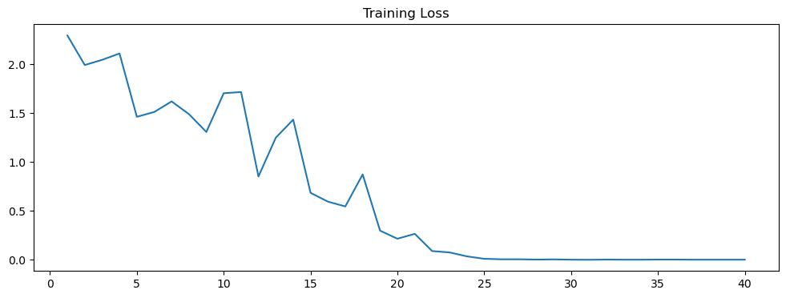

```python
epoch_array = np.arange(1, epochs+1)

plt.figure(figsize=(12,4))
plt.plot(epoch_array, loss_array)
plt.title("Training Loss")
plt.xlabel="Epochs"
plt.ylabel="Loss"
```

Show accuracy from test set

```python
print(f"Accuracy on test set: {prediction(test_data, simple_cnn)}%")
```

```
Accuracy on test set: 50.333%
```

Our simple model has reasonable accuracy, but it could definitely be improved. Let's look at optimising the model.

### Model Optimisation

- **Activation functions** are a key part of the backpropagation stages of the CNN execution. They help to determine which hidden neurons should be activated in order to obtain the desired output. There are many different activation functions, however, we will be focusing on two of the more commonly used functions from recent research:
  - The **ReLU** (Rectified Linear Unit) function is oftentimes the default activation function used when building models. Its significance comes from the introduction of non-linearity, fixing the vanishing gradient issue apparent with other functions. It has a simple implementation that can be applied to all layers in our neural network.
  - The **Softmax** function is designed specifically for multiclass classification by converting raw outputs into a probability score. It is often introduced on the output layers of a neural network to allow for easy interpretation of either single value outputs, or graph plots over a number of epochs.

* **Batch Normalisation** can be added within every block of layers and acts as a stabiliser in the learning process, standardising the inputs and reducing the total number of epochs required for training.

### Revisiting the "Simple" Model

Now equipped with the knowledge of potential layers and functions we can add, let's build a new, optimised model. This updated neural network model takes reference from one proposed by Huaysrijan and Pongpinipinyo in their study on Thai Classical Music Instrument Classification [3]. The model alternates between convolutional and max pooling layers with the ReLU function and batch normalisation applied within every block, and finally the Softmax function applied at the end.

Their model can be implemented using the following code:

```python
#Adapted from source [1] and [3]
class CNN(nn.Module):

    def __init__(self):
        super().__init__()
        self.conv1 = nn.Sequential(
            nn.Conv2d(
                in_channels=4,
                out_channels=16,
                kernel_size=3,
                stride=1,
                padding=2
            ),
            nn.ReLU(),
            nn.BatchNorm2d(16),
            nn.MaxPool2d(kernel_size=2)
        )
        self.conv2 = nn.Sequential(
            nn.Conv2d(
                in_channels=16,
                out_channels=32,
                kernel_size=3,
                stride=1,
                padding=2
            ),
            nn.ReLU(),
            nn.BatchNorm2d(32),
            nn.MaxPool2d(kernel_size=2)
        )
        self.conv3 = nn.Sequential(
            nn.Conv2d(
                in_channels=32,
                out_channels=64,
                kernel_size=3,
                stride=1,
                padding=2
            ),
            nn.ReLU(),
            nn.BatchNorm2d(64),
            nn.MaxPool2d(kernel_size=2)
        )

        self.conv4 = nn.Sequential(
            nn.Conv2d(
                in_channels=64,
                out_channels=128,
                kernel_size=3,
                stride=1,
                padding=2
            ),
            nn.ReLU(),
            nn.BatchNorm2d(128),
            nn.MaxPool2d(kernel_size=2)
        )

        self.flatten = nn.Flatten()
        self.linear = nn.Linear(128 * 12 * 8, 10)
        self.softmax = nn.Softmax(dim=1)

    def forward(self, input_data):
        x = self.conv1(input_data)
        x = self.conv2(x)
        x = self.conv3(x)
        x = self.conv4(x)
        x = self.flatten(x)
        logits = self.linear(x)
        predictions = self.softmax(logits)
        return predictions

cnn = CNN()
summary(cnn, (4, 168, 108))
```

```
----------------------------------------------------------------
        Layer (type)               Output Shape         Param #
================================================================
            Conv2d-1         [-1, 16, 170, 110]             592
              ReLU-2         [-1, 16, 170, 110]               0
       BatchNorm2d-3         [-1, 16, 170, 110]              32
         MaxPool2d-4           [-1, 16, 85, 55]               0
            Conv2d-5           [-1, 32, 87, 57]           4,640
              ReLU-6           [-1, 32, 87, 57]               0
       BatchNorm2d-7           [-1, 32, 87, 57]              64
         MaxPool2d-8           [-1, 32, 43, 28]               0
            Conv2d-9           [-1, 64, 45, 30]          18,496
             ReLU-10           [-1, 64, 45, 30]               0
      BatchNorm2d-11           [-1, 64, 45, 30]             128
        MaxPool2d-12           [-1, 64, 22, 15]               0
           Conv2d-13          [-1, 128, 24, 17]          73,856
             ReLU-14          [-1, 128, 24, 17]               0
      BatchNorm2d-15          [-1, 128, 24, 17]             256
        MaxPool2d-16           [-1, 128, 12, 8]               0
          Flatten-17                [-1, 12288]               0
           Linear-18                   [-1, 10]         122,890
          Softmax-19                   [-1, 10]               0
================================================================
Total params: 220,954
Trainable params: 220,954
Non-trainable params: 0
----------------------------------------------------------------
Input size (MB): 0.28
Forward/backward pass size (MB): 14.87
Params size (MB): 0.84
Estimated Total Size (MB): 15.99
----------------------------------------------------------------
```

Let's train our new model:

```python
epochs = 40 #Total number of epochs
#Define our loss function and optimiser
loss_fn = nn.CrossEntropyLoss()
optimiser = torch.optim.Adam(cnn.parameters(), lr=0.0001)

#Define an array to store loss at each epoch
loss_array = np.zeros(epochs, dtype=float)

train(cnn, train_data, train_dataloader, loss_fn, optimiser, epochs, 10)
#Save the model and its parameters
torch.save(cnn.state_dict(), "cnn.pth")
```

```
Epoch: 10
Loss: 2.0785014629364014
---
Epoch: 20
Loss: 1.8549684286117554
---
Epoch: 30
Loss: 1.5094578266143799
---
Epoch: 40
Loss: 1.4628318548202515
---
```

Again, we plot the training loss over the number of epochs:

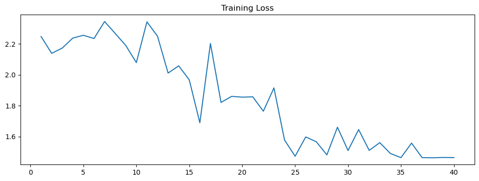

```python
epoch_array = np.arange(1, epochs+1)

plt.figure(figsize=(12,4))
plt.plot(epoch_array, loss_array)
plt.title("Training Loss")
plt.xlabel="Epochs"
plt.ylabel="Loss"
```

And finally, the accuracy on the test set:

```python
print(f"Accuracy on test set: {prediction(test_data, cnn)}%")
```

```
Accuracy on test set: 57.667%
```

Our final accuracy is a slight improvement from our simple model, as expected, but it could still be improved further, as we will discuss this in the evaluation.

## Evaluation

This tutorial is a simplistic look into solving multiclass audio classification problems, and while the final model was an improvement on the original, there could still be further adjustments made to increase accuracy. In this section, we will discuss one of the potential main reasons for underperformance, as well as analysing similar tutorials and comparing them to this one.

### The Dataset

While the GTZAN Dataset is highly regarded, and commonly used, there are two main faults that have arose and can be seen within the implementation during this tutorial:

- **Lack of data**: While there are 100 images per genre, this is still lacking when compared to other audio datasets, like the UrbanSound8k dataset, which contains over 8,000 files across the same number of classes. This issue could be resolved by cropping the audio files to 3 second intervals and generating spectrograms using the other .csv file, effectively multiplying the amount of data by 10. However, this is a very specific case to the GTZAN dataset and is unnecessary to include this additional step in what was intended to be a general tutorial that aims to be applicable to any audio dataset.
- **Variation within the same class**: It is expected that audio files will differ from sample to sample, and with clips of musical pieces rather than instruments used, this is all but guaranteed. However, paired with the lack of data, the pre-made spectrograms differing within the same genre will negatively affect the training of the neural network, unless it is fine-tuned after every set number of epochs.

### Other Sources

Multiclass audio classification is not a unique problem and has been explored and solved with many types of neural networks with a range of datasets. Despite this, oftentimes the implementation of these models is not public or restricted to a certain coding language. Two main sources were adapted or referenced within this tutorial and are discussed below:

- **PyTorch for Audio + Music Processing (The Sound of AI)** [1]: The code used in this tutorial was mainly adapted from this video series, exploring a similar classification problem. The series of 10 videos explores the topic in high detail and the follow-along style of coding furthers the viewer's understanding of the inner workings of the code. Online tutorials often lack in this way, as large chunks of code with barely any commenting is presented within an article, but this video series takes a slow pace for implementation and is easy to follow. Only a few sections were adapted from the series, as it includes a different dataset, other methods at manipulating spectrograms using Pytorch, and is limited to mainly training the neural network, rather than also testing on a whole dataset. This the biggest difference between this tutorial and the video series: the inclusion of the accuracy metric and corresponding graphs for loss.
- **CNNs for Audio Classification (Papia Nandi)** [2]: There are a range of tutorials for multiclass audio classification, this article by Nandi is presented and executed well, with clear steps and images to guide a novice along. However, one of the main issues with most online tutorials, not just Nandi's, is that they exclusively use TensorFlow rather than Pytorch. This choice is most likely because of the more practical and user friendly implementation that comes with TensorFlow, as well as its adaptability when building neural network models. Therefore, this tutorial differs and presents a similar subject using different libraries. Additionally, as classification problems vary, even slightly, between different articles, finding a more generalised tutorial that can be applied to multiple audio datasets is more difficult, which is another aim this tutorial strived to achieve.

## Conclusion

In this tutorial, we discussed how a convolutional neural network implemented using Pytorch can be adapted to classify a dataset of audio files using spectrograms. This is a general case, using a single dataset, and it is highly recommended that you experiment with the neural network model or the choice of dataset to further your understanding and achieve better results.

## References

[1]: Velardo, Valerio. "PyTorch for Audio + Music Processing" YouTube, uploaded by Valerio Velardo - The Sound of AI, 2021, https://youtube.com/playlist?list=PL-wATfeyAMNoirN4idjev6aRu8ISZYVWm&si=060wdbT6Mge1Vnjf

[2]: Papia Nandi. "CNNs for Audio Classification", Published in Towards Data Science, 2021, https://towardsdatascience.com/cnns-for-audio-classification-6244954665ab

[3]: Huaysrijan and Pongpinipinyo. "Deep Convolution Neural Network for Thai Classical Music Instruments Sound Recognition", Published in 2021 25th International Computer Science and Engineering Conference (ICSEC), 2021, https://ieeexplore.ieee.org/document/9684611

[4]: Tom Wyllie. "How to convert a .wav file to a spectrogram in python3", Stack Overflow, 2017, https://stackoverflow.com/questions/44787437/how-to-convert-a-wav-file-to-a-spectrogram-in-python3

Back to the top